# **Wine Quality Prediction**

**About Data**

**[Data Cleaning and Preprocessing]**

**[Exploratory Data Analysis]**

- Hypothesis Analysis
- Creating scatter plot, histogram of the dataset
- Analyzing correlations,

**[Model Training and Evaluation]**

- Splitting the dataset into training and testing sets
- Training different ML models (LR,DT, LightGBM, RF)
- Making predictions on the testing set and evaluating each model's performance by RMSE

**[Conclusion]**

- Model Evaluation

# 1. Data Cleaning and Preprocessing

This code reads two wine datasets, one containing information about red wines and another containing information about white wines. A new column 'type' is added to each dataset to identify the type of wine. Then, both datasets are concatenated into a single dataset called 'wine'. **Thre is no NaN.**

```python
import pandas as pd
import numpy as np
import seaborn as sns
import matplotlib.pyplot as plt
```

```python
redwine = pd.read_csv("/content/drive/MyDrive/Dataset/winequality-red.csv")
redwine['type'] = 'red'
whitewine = pd.read_csv("/content/drive/MyDrive/Dataset/winequality-white.csv")
whitewine['type'] = 'white'
```

```python
wine = pd.concat([redwine, whitewine], ignore_index=True)
wine.shape
```

```
(6497, 13)
```

```python
wine.head()
```

|  | fixed acidity | volatile acidity | citric acid | residual sugar | chlorides | free sulfur dioxide | total sulfur dioxide | density | pH | sulphates | alcohol | quality | type |
| --- | --- | --- | --- | --- | --- | --- | --- | --- | --- | --- | --- | --- | --- |
| 0 | 7.4 | 0.70 | 0.00 | 1.9 | 0.076 | 11.0 | 34.0 | 0.9978 | 3.51 | 0.56 | 9.4 | 5 | red |
| 1 | 7.8 | 0.88 | 0.00 | 2.6 | 0.098 | 25.0 | 67.0 | 0.9968 | 3.20 | 0.68 | 9.8 | 5 | red |
| 2 | 7.8 | 0.76 | 0.04 | 2.3 | 0.092 | 15.0 | 54.0 | 0.9970 | 3.26 | 0.65 | 9.8 | 5 | red |
| 3 | 11.2 | 0.28 | 0.56 | 1.9 | 0.075 | 17.0 | 60.0 | 0.9980 | 3.16 | 0.58 | 9.8 | 6 | red |
| 4 | 7.4 | 0.70 | 0.00 | 1.9 | 0.076 | 11.0 | 34.0 | 0.9978 | 3.51 | 0.56 | 9.4 | 5 | red |

# 2. EDA

Compute summary statistics for all numerical features

- Exploring the distribution of the data by creating frequency tables or probability distributions
- Computing summary statistics such as mean, median, mode, variance, and standard deviation to understand the central tendency and variability of the data
- Visualizing the data using histograms, scatter plots, box plots, or heatmaps to identify patterns or relationships

```python
wine.describe()
```

|  | fixed acidity | volatile acidity | citric acid | residual sugar | chlorides | free sulfur dioxide | total sulfur dioxide | density | pH | sulphates | alcohol | quality |
| --- | --- | --- | --- | --- | --- | --- | --- | --- | --- | --- | --- | --- |
| count | 6497.000000 | 6497.000000 | 6497.000000 | 6497.000000 | 6497.000000 | 6497.000000 | 6497.000000 | 6497.000000 | 6497.000000 | 6497.000000 | 6497.000000 | 6497.000000 |
| mean | 7.215307 | 0.339666 | 0.318633 | 5.443235 | 0.056034 | 30.525319 | 115.744574 | 0.994697 | 3.218501 | 0.531268 | 10.491801 | 5.818378 |
| std | 1.296434 | 0.164636 | 0.145318 | 4.757804 | 0.035034 | 17.749400 | 56.521855 | 0.002999 | 0.160787 | 0.148806 | 1.192712 | 0.873255 |
| min | 3.800000 | 0.080000 | 0.000000 | 0.600000 | 0.009000 | 1.000000 | 6.000000 | 0.987110 | 2.720000 | 0.220000 | 8.000000 | 3.000000 |
| 25% | 6.400000 | 0.230000 | 0.250000 | 1.800000 | 0.038000 | 17.000000 | 77.000000 | 0.992340 | 3.110000 | 0.430000 | 9.500000 | 5.000000 |
| 50% | 7.000000 | 0.290000 | 0.310000 | 3.000000 | 0.047000 | 29.000000 | 118.000000 | 0.994890 | 3.210000 | 0.510000 | 10.300000 | 6.000000 |
| 75% | 7.700000 | 0.400000 | 0.390000 | 8.100000 | 0.065000 | 41.000000 | 156.000000 | 0.996990 | 3.320000 | 0.600000 | 11.300000 | 6.000000 |
| max | 15.900000 | 1.580000 | 1.660000 | 65.800000 | 0.611000 | 289.000000 | 440.000000 | 1.038980 | 4.010000 | 2.000000 | 14.900000 | 9.000000 |

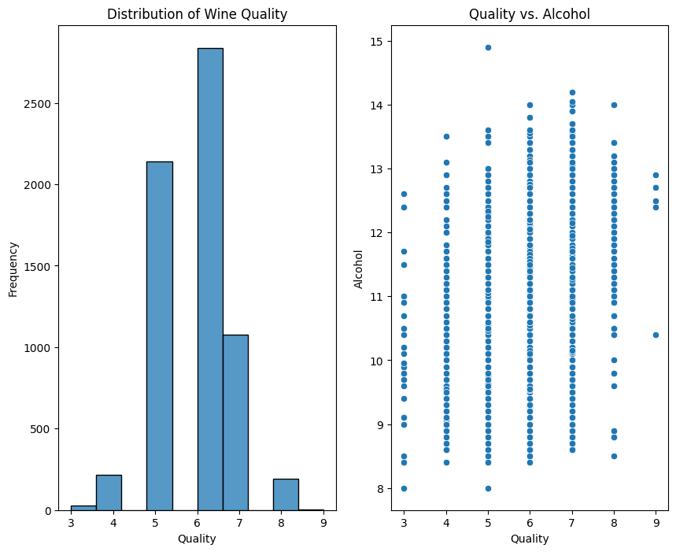

```python
fig, axs = plt.subplots(1, 2, figsize=(10, 8))

sns.histplot(data=wine, x='quality', bins=10, ax=axs[0])
axs[0].set_xlabel('Quality')
axs[0].set_ylabel('Frequency')
axs[0].set_title('Distribution of Wine Quality')

sns.scatterplot(data=wine, x="quality", y="alcohol", ax=axs[1])
axs[1].set_xlabel("Quality")
axs[1].set_ylabel("Alcohol")
axs[1].set_title('Quality vs. Alcohol')

plt.show()
```

```python
wine.groupby('type')['quality'].describe()
```

| type | count | mean | std | min | 25% | 50% | 75% | max |
| --- | --- | --- | --- | --- | --- | --- | --- | --- |
| red | 1599.0 | 5.636023 | 0.807569 | 3.0 | 5.0 | 6.0 | 6.0 | 8.0 |
| white | 4898.0 | 5.877909 | 0.885639 | 3.0 | 5.0 | 6.0 | 6.0 | 9.0 |

```python
wine.groupby('type')['quality'].quantile([0, 0.25, 0.5, 0.75, 1]).unstack('type')
```

| type | red | white |
| --- | --- | --- |
| 0.00 | 3.0 | 3.0 |
| 0.25 | 5.0 | 5.0 |
| 0.50 | 6.0 | 6.0 |
| 0.75 | 6.0 | 6.0 |
| 1.00 | 8.0 | 9.0 |

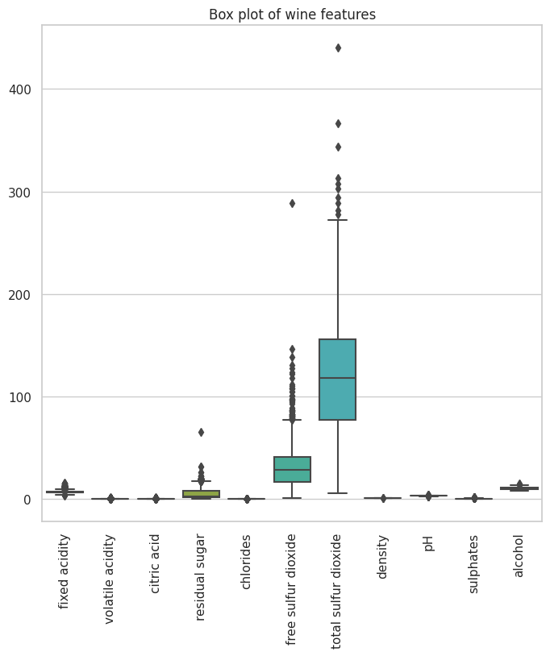

```python
sns.set(style='whitegrid')
fig, axs = plt.subplots(figsize=(8, 8))
axs = sns.boxplot(data=wine.drop(columns=['type', 'quality']), orient='l')
axs.set_title('Box plot of wine features')
axs.set_xticklabels(axs.get_xticklabels(), rotation=90)
plt.show()
```

**Hypothesis Testing**

- H0: There is no difference between the type of wine and quality.
- H1: There is a difference between the type of wine and quality.

```python
from scipy.stats import ttest_ind

red_wine = wine[wine['type'] == 'red']['quality']
white_wine = wine[wine['type'] == 'white']['quality']

t_stat, p_val = ttest_ind(red_wine, white_wine, equal_var=False)
print("t-statistic:", t_stat)
print("p-value:", p_val)
```

```
t-statistic: -10.149363059143164
p-value: 8.168348870049682e-24
```

**Insight:** Based on the t-statistic of -10.15 and the very low p-value of 8.17e-24, we can reject the null hypothesis. This means that there is a significant difference in the quality ratings of red and white wines.

```python
wine.groupby('type')['quality'].aggregate(['std','mean'])
```

| type | std | mean |
| --- | --- | --- |
| red | 0.807569 | 5.636023 |
| white | 0.885639 | 5.877909 |

**Correlation Matrix**

- Calculate the correlation between all features
- Visualize the correlation matrix using a heatmap

```python
wine_corr = wine.corr()
wine_corr
```

|  | fixed acidity | volatile acidity | citric acid | residual sugar | chlorides | free sulfur dioxide | total sulfur dioxide | density | pH | sulphates | alcohol | quality |
| --- | --- | --- | --- | --- | --- | --- | --- | --- | --- | --- | --- | --- |
| fixed acidity | 1.000000 | 0.219008 | 0.324436 | -0.111981 | 0.298195 | -0.282735 | -0.329054 | 0.458910 | -0.252700 | 0.299568 | -0.095452 | -0.076743 |
| volatile acidity | 0.219008 | 1.000000 | -0.377981 | -0.196011 | 0.377124 | -0.352557 | -0.414476 | 0.271296 | 0.261454 | 0.225984 | -0.037640 | -0.265699 |
| citric acid | 0.324436 | -0.377981 | 1.000000 | 0.142451 | 0.038998 | 0.133126 | 0.195242 | 0.096154 | -0.329808 | 0.056197 | -0.010493 | 0.085532 |
| residual sugar | -0.111981 | -0.196011 | 0.142451 | 1.000000 | -0.128940 | 0.402871 | 0.495482 | 0.552517 | -0.267320 | -0.185927 | -0.359415 | -0.036980 |
| chlorides | 0.298195 | 0.377124 | 0.038998 | -0.128940 | 1.000000 | -0.195045 | -0.279630 | 0.362615 | 0.044708 | 0.395593 | -0.256916 | -0.200666 |
| free sulfur dioxide | -0.282735 | -0.352557 | 0.133126 | 0.402871 | -0.195045 | 1.000000 | 0.720934 | 0.025717 | -0.145854 | -0.188457 | -0.179838 | 0.055463 |
| total sulfur dioxide | -0.329054 | -0.414476 | 0.195242 | 0.495482 | -0.279630 | 0.720934 | 1.000000 | 0.032395 | -0.238413 | -0.275727 | -0.265740 | -0.041385 |
| density | 0.458910 | 0.271296 | 0.096154 | 0.552517 | 0.362615 | 0.025717 | 0.032395 | 1.000000 | 0.011686 | 0.259478 | -0.686745 | -0.305858 |
| pH | -0.252700 | 0.261454 | -0.329808 | -0.267320 | 0.044708 | -0.145854 | -0.238413 | 0.011686 | 1.000000 | 0.192123 | 0.121248 | 0.019506 |
| sulphates | 0.299568 | 0.225984 | 0.056197 | -0.185927 | 0.395593 | -0.188457 | -0.275727 | 0.259478 | 0.192123 | 1.000000 | -0.003029 | 0.038485 |
| alcohol | -0.095452 | -0.037640 | -0.010493 | -0.359415 | -0.256916 | -0.179838 | -0.265740 | -0.686745 | 0.121248 | -0.003029 | 1.000000 | 0.444319 |
| quality | -0.076743 | -0.265699 | 0.085532 | -0.036980 | -0.200666 | 0.055463 | -0.041385 | -0.305858 | 0.019506 | 0.038485 | 0.444319 | 1.000000 |

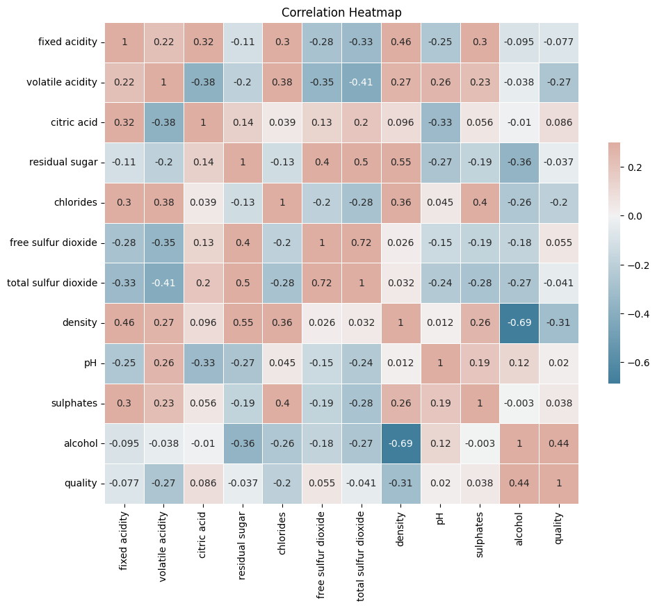

```python
plt.figure(figsize=(11, 9))
cmap = sns.diverging_palette(230, 20, as_cmap=True)
sns.heatmap(wine.corr(), annot=True, cmap=cmap, vmax=.3, center=0,
            square=False, linewidths=.5, cbar_kws={"shrink": .5})
plt.title('Correlation Heatmap')
plt.show()
```

**Insights:**

```python
wine_corr.loc[np.abs(wine_corr['quality']) > 0.2, 'quality']
```

```
volatile acidity   -0.265699
chlorides          -0.200666
density            -0.305858
alcohol             0.444319
quality             1.000000
Name: quality, dtype: float64
```

**PairGrid:** This code generates a random sample of 200 red and white wines from the original wine dataset, and then creates a pair plot (PairGrid) of the variables 'quality', 'alcohol', 'residual sugar', and 'type' with hue set to 'type' (red or white).

- The diagonal plot shows a histogram of each variable, while the off-diagonal shows a scatter plot of each combination of variables.
- The plot visualize the relationships between the variables and their distributions for red and white wines.

```python
red_sample = wine.loc[wine['type']=='red', :]
white_sample = wine.loc[wine['type']=='white', :]

red_idx = np.random.choice(red_sample.index, replace=True, size=200)
white_idx = np.random.choice(white_sample.index, replace=True, size=200)
```

```python
wine_sample = pd.concat([red_sample.loc[red_idx, ], white_sample.loc[white_idx, ]])
wine_sample.head()
```

|  | fixed acidity | volatile acidity | citric acid | residual sugar | chlorides | free sulfur dioxide | total sulfur dioxide | density | pH | sulphates | alcohol | quality | type |
| --- | --- | --- | --- | --- | --- | --- | --- | --- | --- | --- | --- | --- | --- |
| 110 | 7.8 | 0.56 | 0.19 | 1.8 | 0.104 | 12.0 | 47.0 | 0.99640 | 3.19 | 0.93 | 9.5 | 5 | red |
| 1010 | 8.9 | 0.28 | 0.45 | 1.7 | 0.067 | 7.0 | 12.0 | 0.99354 | 3.25 | 0.55 | 12.3 | 7 | red |
| 18 | 7.4 | 0.59 | 0.08 | 4.4 | 0.086 | 6.0 | 29.0 | 0.99740 | 3.38 | 0.50 | 9.0 | 4 | red |
| 1486 | 6.8 | 0.68 | 0.21 | 2.1 | 0.070 | 9.0 | 23.0 | 0.99546 | 3.38 | 0.60 | 10.3 | 5 | red |
| 238 | 7.2 | 0.63 | 0.00 | 1.9 | 0.097 | 14.0 | 38.0 | 0.99675 | 3.37 | 0.58 | 9.0 | 6 | red |

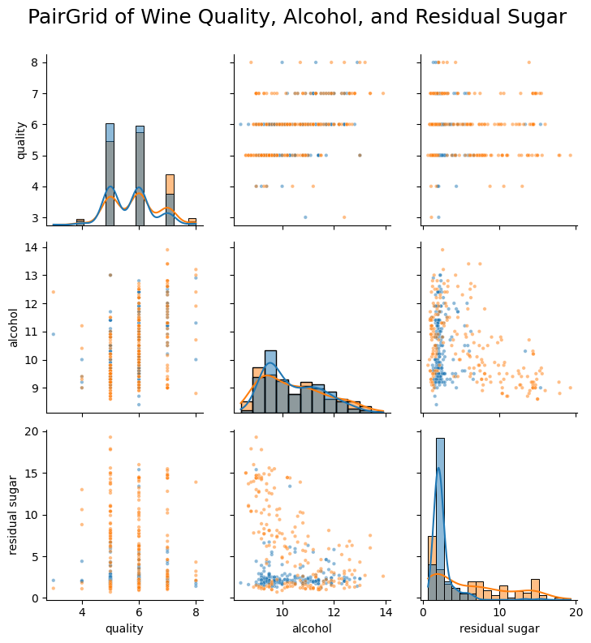

```python
g = sns.PairGrid(wine_sample[['quality', 'alcohol', 'residual sugar','type']],
                 hue='type')
g.map_diag(sns.histplot, kde=True)
g.map_offdiag(sns.scatterplot, s=10, alpha=0.5)
g.fig.suptitle('PairGrid of Wine Quality, Alcohol, and Residual Sugar', y=1.05, fontsize=18)
plt.show()
```

# 3. ML Modeling (Linear Regression, Decision Tree Regressor, LightGBM, Random Forest)

The code performs several steps to evaluate different models' performance in predicting the quality of wine. It first splits the dataset into training and testing sets. Then, it builds four regression models, including linear regression, decision tree regressor, lightGBM, and random forest. Finally, it evaluates each model's performance using mean squared error as the metric.

**Import ML Libraries and Split Train & Test Model**

```python
from sklearn.model_selection import train_test_split
from sklearn.linear_model import LinearRegression
from sklearn.tree import DecisionTreeRegressor
from sklearn.ensemble import RandomForestRegressor
import lightgbm as lgb
from sklearn.metrics import mean_squared_error
```

```python
X = wine.drop(['quality','type'], axis=1)
y = wine['quality']
```

```python
X_train, X_test, y_train, y_test = train_test_split(X,y, test_size =0.3, random_state = 100)
```

**a) Linear Regression**

```python
regressor = LinearRegression()
regressor.fit(X_train,y_train)
```

```
LinearRegression()
```

```python
y_pred_lr = regressor.predict(X_test)
lr_rmse = mean_squared_error(y_test, y_pred_lr, squared=False)
print("Linear Regression RMSE:", lr_rmse)
```

```
Linear Regression RMSE: 0.7288717988684669
```

**b) Decision Tree Regression**

```python
dt_reg = DecisionTreeRegressor(random_state=100)
dt_reg.fit(X_train, y_train)
```

```
DecisionTreeRegressor(random_state=100)
```

```python
y_pred_dt = dt_reg.predict(X_test)
dt_rmse = mean_squared_error(y_test, y_pred_dt, squared=False)
print("Decision Tree Regression RMSE:", dt_rmse)
```

```
Decision Tree Regression RMSE: 0.8738362224065467
```

**c) LightGBM**

```python
train_data = lgb.Dataset(X_train, y_train)

params = {'objective': 'regression', 'metric': 'rmse', 'num_leaves': 31, 'learning_rate': 0.05} # hyperparameters

lgbm_model = lgb.train(params, train_data, num_boost_round=100)
```

[output not shown]

```python
y_pred_lgbm = lgbm_model.predict(X_test)

# calculate the root mean squared error
lgbm_rmse = np.sqrt(mean_squared_error(y_test, y_pred_lgbm))
print('LightGBM RMSE:', lgbm_rmse)
```

```
LightGBM RMSE: 0.6440732510382374
```

**d) Random Forest Regressor**

```python
rf_regressor = RandomForestRegressor(n_estimators=100, random_state=100)
rf_regressor.fit(X_train, y_train)
```

```
RandomForestRegressor(random_state=100)
```

```python
y_pred_rf = rf_regressor.predict(X_test)

rf_rmse = np.round(np.sqrt(mean_squared_error(y_test, y_pred_rf)), 2)
print("Random Forest RMSE:", rf_rmse)
```

```
Random Forest RMSE: 0.6
```

**Compare Results: 'Linear Regression', 'Decision Tree Regression', 'LightGBM', 'Random Forest'**

```python
results = pd.DataFrame({'Model': ['Linear Regression', 'Decision Tree Regression', 'LightGBM', 'Random Forest'],
                        'RMSE': [lr_rmse, dt_rmse, lgbm_rmse, rf_rmse]})

print(results)
```

```
                      Model      RMSE
0         Linear Regression  0.728872
1  Decision Tree Regression  0.873836
2                  LightGBM  0.644073
3             Random Forest  0.600000
```

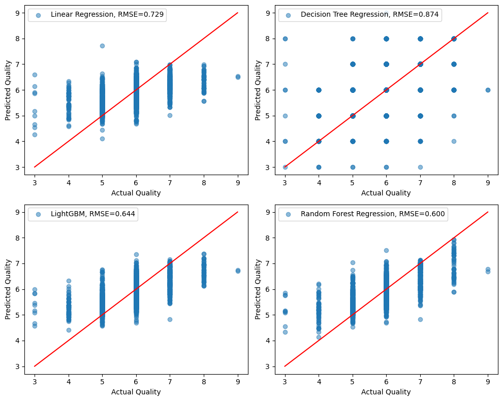

```python
fig, axs = plt.subplots(2, 2, figsize=(10, 8))
axs = axs.flatten()

models = [('Linear Regression', y_pred_lr, lr_rmse),
          ('Decision Tree Regression', y_pred_dt, dt_rmse),
          ('LightGBM', y_pred_lgbm, lgbm_rmse),
          ('Random Forest Regression', y_pred_rf, rf_rmse)]

for i, model in enumerate(models):
    ax = axs[i]
    ax.scatter(y_test, model[1], alpha=0.5, label=f'{model[0]}, RMSE={model[2]:.3f}')
    ax.plot([3,9],[3,9], color='red')
    ax.set_xlabel('Actual Quality')
    ax.set_ylabel('Predicted Quality')
    ax.legend()

plt.tight_layout()
plt.show()
```

# **4. Conclusion:**

Based on the root mean squared error (RMSE) values, it seems that Random Forest Regression has the lowest error among the models you have trained with an RMSE of 0.6. The LightGBM Regression model also has a relatively low RMSE of 0.644. Linear Regression and Decision Tree Regression models have higher RMSE values of 0.728 and 0.873, respectively. Therefore, Random Forest Regression seems to be the best model for the given dataset based on the evaluation metric RMSE.

```python
!jupyter nbconvert --to html Wine_Quality.ipynb
```